# Projet LSTAT2110(A) – Analyse de données

BARTHELEMI Lauriane , 56281400, BIRE2M, MARTELEE Baudouin , 43191400, DATS2M

# Introduction

La violence est un excellent moyen d’extérioriser tous les tracas que nous gardons profondément au fond de nous. Cependant, il ne faut pas qu’elle soit destructrice et cela implique qu’elle soit canalisée. On peut alors l’exprimer sous différentes formes tels que les sports de combat. Tous deux passionnés de jiu jitsu brésilien et membres du même club, nous avons décidé de nous pencher un peu plus sur le sujet.

# Présentation des données, analyse descriptive

## Description du dataset et motivation de l’utilisation de cette base de données

Le dataset porte le nom de dataset UFC. L’UFC ou de son nom entier l’Ultimate Fighting Championship est la plus grande organisation au monde de sport de combat Mixed Martial Art (MMA).

Cette base de données contient 5144 combats qui se sont déroulées entre 1993 et 2019. Elle comprend pour chaque combat, 2 combattants qui, pour être distingués portent les noms de : combattant Bleu (B_fighter) et combattant Rouge (R_fighter). On a différentes informations à propos de l’organisation du combat tel que la date du combat, l’endroit où se déroule celui-ci, la catégorie de poids , le nombre de rounds que comporte le combat, l’arbitre qui régulera le combat ou bien encore s’il s’agit d’un combat pour le titre de champion du monde. En plus de cela, on peut trouver, pour chaque combattant, des statistiques personelles physiologiques ou encore des performances réalisées lors du combat.

Vous pourrez retrouver toutes les informations relatives aux différentes règles de mma en annexe.

## Importation des données

On importe les données

```r
# Import des données à partir du fichier csv
dataUFC <- read.csv('data.csv',header = TRUE,sep = ',', dec = '.')
dim(dataUFC)
```

```
[1] 5144  145
```

## Selection des variables intéressantes.

Comme on peut le constater, le nombre de variable est conséquent (145). Une des demandes de ce projet est l’analyse en composantes principales. L’ACP est basée sur de la visualisation. Donc avoir un trop grand nombre de variables est contre productif. Il va donc nous falloir restreindre le nombre de variables et sélectionner des variables intéressantes.

Dans un premier temps, Nous allons nous concentrer sur l’analyse d’un combattant pour chaque combat, dans ce cas-ci, nous avons choisi de se concentrer sur le combattant Blue. On sélectionne donc toutes les variables en rapport avec notre combattant Blue. L’objectif dans ce projet étant de constater quelles compétences ou distinctions physiques permettent de remporter un combat mais aussi de voir les liens entre les différentes techniques de combats et comment celles-ci peuvent influencer le résultat du combat.

```r
dataUFC1 = dataUFC[1:1050,c(1:76,144)]
colnames(dataUFC1)
```

```
 [1] "R_fighter"                    "B_fighter"
 [3] "Referee"                      "date"
 [5] "location"                     "Winner"
 [7] "title_bout"                   "weight_class"
 [9] "no_of_rounds"                 "B_current_lose_streak"
[11] "B_current_win_streak"         "B_draw"
[13] "B_avg_BODY_att"               "B_avg_BODY_landed"
[15] "B_avg_CLINCH_att"             "B_avg_CLINCH_landed"
[17] "B_avg_DISTANCE_att"           "B_avg_DISTANCE_landed"
[19] "B_avg_GROUND_att"             "B_avg_GROUND_landed"
[21] "B_avg_HEAD_att"               "B_avg_HEAD_landed"
[23] "B_avg_KD"                     "B_avg_LEG_att"
[25] "B_avg_LEG_landed"             "B_avg_PASS"
[27] "B_avg_REV"                    "B_avg_SIG_STR_att"
[29] "B_avg_SIG_STR_landed"         "B_avg_SIG_STR_pct"
```

[output cut: 24 more lines]

# Selection des variables intéressantes

Pour que vous vérifiez que les données ainsi que les analyses soient cohérentes, on ne va séletionner que les combattants participant à un combat pour le titre de champion du monde. Ces combattants étant connus, leurs compétences sont souvent connus du grand public (même le public hors sport de combat, example : Conor McGregor). Il est donc plus facile pour vous de comprendre les résultats des analyses.

```r
typeof(dataUFC1$title_bout)
```

```
[1] "integer"
```

```r
dataUFC2 <- dataUFC1[which(dataUFC1$title_bout ==  "True"),]
```

Pour info : un takedown est un mouvement de judo, jiujitsu brésilien ou de lutte qui permet de mettre un adversaire à terre.

```r
dataFinal = dataUFC2[,c("B_fighter","weight_class","B_current_win_streak","B_longest_win_streak","B_age","B_win_by_Submission","B_win_by_KO.TKO","B_avg_HEAD_landed","B_avg_LEG_landed","B_avg_GROUND_landed","B_avg_HEAD_att","B_avg_LEG_att","B_avg_GROUND_att")]
```

Nous allons nous concentrer sur les combattants masculins car d’une part les combattants masculins représentent une grande majorité des combats et d’autres part, cela permet de n’avoir qu’une seule catégorie d’individus.

```r
dataFinalWithoutWomen <- dataFinal[!grepl("^Women's.+", dataFinal$weight_class),]
dataCleaned <- dataFinalWithoutWomen[complete.cases(dataFinalWithoutWomen), ]
```

Pour pouvoir mettre en place l’analyse en composante principale, nous allons mettre le nom de combattants en nom de ligne et nous allons en même temps supprimer les doublons de combattants car on ne veut pas prendre en compte plusieurs combats d’un même combattant pour cette analyse.

```r
#Mettre  les noms de combattants en noms de lignes
dataCleaned = dataCleaned[!duplicated(dataCleaned$B_fighter), ]
rownames(dataCleaned) = dataCleaned$B_fighter
dataCleaned$B_fighter = NULL
head(dataCleaned)
```

| weight_class | B_current_win_streak | B_longest_win_streak | B_age | B_win_by_Submission | B_win_by_KO.TKO | B_avg_HEAD_landed | B_avg_LEG_landed | B_avg_GROUND_landed | B_avg_HEAD_att | B_avg_LEG_att | B_avg_GROUND_att |
| --- | --- | --- | --- | --- | --- | --- | --- | --- | --- | --- | --- |
| Bantamweight | 4 | 4 | 31 | 1 | 2 | 11.20000 | 5.400000 | 2.000000 | 48.60000 | 7.600000 | 2.600000 |
| Lightweight | 3 | 4 | 30 | 3 | 8 | 40.66667 | 6.619048 | 5.095238 | 90.47619 | 8.095238 | 8.095238 |
| Middleweight | 5 | 5 | 29 | 0 | 2 | 32.60000 | 17.200000 | 1.600000 | 77.40000 | 20.200000 | 2.000000 |
| Light Heavyweight | 3 | 3 | 30 | 1 | 5 | 24.10000 | 2.900000 | 2.200000 | 54.70000 | 3.200000 | 2.900000 |
| Welterweight | 9 | 9 | 31 | 1 | 1 | 39.11111 | 7.555556 | 23.777778 | 90.22222 | 8.888889 | 33.222222 |
| Flyweight | 4 | 4 | 32 | 1 | 7 | 45.73333 | 11.133333 | 12.400000 | 133.06667 | 14.533333 | 16.533333 |

Maintenant notre dataset est prêt pour les différentes analyses. Il comporte 31 observations différentes et 12 variables.

## Analyse descriptive

### Statistique descriptive

Nous allons maintenant faire une analyse descriptive des données afin de pouvoir avoir une meilleure compréhension du dataset. Dans un premier temps, nous allons montrer une matrice de corrélation afin de voir les liens entre les différentes variables continues de notre analyse. install.packages(“corrplot”)

```r
summary(dataCleaned)
```

```
            weight_class B_current_win_streak B_longest_win_streak
 Light Heavyweight:5     Min.   : 0.000       Min.   : 0.000
 Welterweight     :5     1st Qu.: 2.000       1st Qu.: 4.000
 Flyweight        :4     Median : 3.000       Median : 5.000
 Heavyweight      :4     Mean   : 4.226       Mean   : 5.645
 Lightweight      :4     3rd Qu.: 5.500       3rd Qu.: 7.000
 Middleweight     :4     Max.   :13.000       Max.   :13.000
 (Other)          :5
     B_age       B_win_by_Submission B_win_by_KO.TKO  B_avg_HEAD_landed
 Min.   :24.00   Min.   :0.000       Min.   : 0.000   Min.   : 2.00
 1st Qu.:28.50   1st Qu.:0.000       1st Qu.: 2.000   1st Qu.:21.75
 Median :31.00   Median :1.000       Median : 3.000   Median :27.43
 Mean   :30.52   Mean   :1.516       Mean   : 3.774   Mean   :27.74
 3rd Qu.:32.50   3rd Qu.:2.000       3rd Qu.: 5.000   3rd Qu.:37.52
 Max.   :39.00   Max.   :9.000       Max.   :11.000   Max.   :45.73

 B_avg_LEG_landed  B_avg_GROUND_landed B_avg_HEAD_att   B_avg_LEG_att
 Min.   : 0.7143   Min.   : 1.000      Min.   : 11.00   Min.   : 0.7273
 1st Qu.: 2.1833   1st Qu.: 2.636      1st Qu.: 51.30   1st Qu.: 2.5667
 Median : 5.3750   Median : 5.688      Median : 75.50   Median : 7.0000
 Mean   : 5.4296   Mean   : 7.449      Mean   : 72.39   Mean   : 6.8331
 3rd Qu.: 6.7875   3rd Qu.:10.980      3rd Qu.: 90.35   3rd Qu.: 8.4545
 Max.   :17.2000   Max.   :23.778      Max.   :133.07   Max.   :20.2000

 B_avg_GROUND_att
 Min.   : 1.667
 1st Qu.: 5.410
 Median : 8.455
 Mean   :10.797
 3rd Qu.:15.133
 Max.   :33.222
```

### Matrice de corrélation

Voici 2 manières de visualiser la corrélations entre les variables:

```r
library(corrplot)
quantitativeVariables <- dataCleaned[7:12]
dataUFC.cor <- cor(quantitativeVariables)
dataUFC.cor
```

```
                    B_avg_HEAD_landed B_avg_LEG_landed B_avg_GROUND_landed
B_avg_HEAD_landed           1.0000000        0.5089706          0.25839373
B_avg_LEG_landed            0.5089706        1.0000000          0.17848006
B_avg_GROUND_landed         0.2583937        0.1784801          1.00000000
B_avg_HEAD_att              0.9262812        0.4213820          0.08338993
B_avg_LEG_att               0.5019298        0.9928699          0.19203369
B_avg_GROUND_att            0.2057809        0.1469704          0.98927955
                    B_avg_HEAD_att B_avg_LEG_att B_avg_GROUND_att
B_avg_HEAD_landed       0.92628123     0.5019298       0.20578088
B_avg_LEG_landed        0.42138200     0.9928699       0.14697042
B_avg_GROUND_landed     0.08338993     0.1920337       0.98927955
B_avg_HEAD_att          1.00000000     0.4170185       0.03396246
B_avg_LEG_att           0.41701849     1.0000000       0.15985547
B_avg_GROUND_att        0.03396246     0.1598555       1.00000000
```

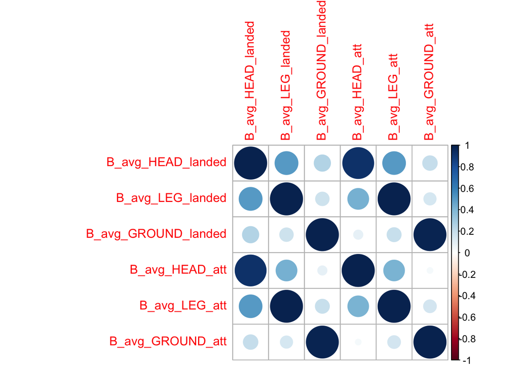

```r
corrplot(dataUFC.cor)
```

On peut constater qu’une variable _att est fortement correlée à une variable _landed ce qui est logique car un combattant qui essaye d’effectuer un mouvement de combat (_att) a une chance de toucher son adversaire. On peut aussi remarquer que la corrélation est faible pour certaines variables : si on prends les attaques de mise au sol par exemple (_att et _landed) on remarque que les corrélations avec les techniques de striking sont faibles. Ce qui est normal car quand un combattant tente un takedown, il se concentre moins à donner des coups à son adversaire car il doit le déstabiliser pour l’amener au sol. Il n’y a cependant pas de corrélations négatives entre les variables analysées.

# Analyse en composantes principales

## PCA

Pour pouvoir effectuer une analyse en composante principale, on va devoir utiliser le package FactoMineR. Nous devons sélectionner les variables continues de notre dataset final. Après cela, nous allons visualiser les valeurs propres en fonction des composantes afin de sélectionner quelles composantes nous devons choisir pour notre analyse.

```r
library(FactoMineR)
```

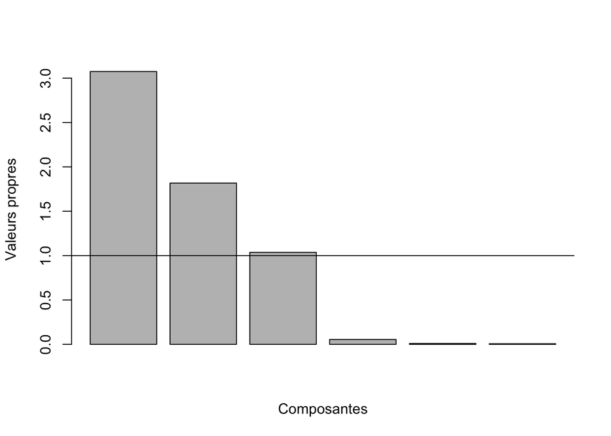

```r
res <- PCA(quantitativeVariables, graph = FALSE, ncp = 6)
barplot(res$eig[,"eigenvalue"],xlab = "Composantes",ylab = "Valeurs propres")
abline(h = 1)
```

```r
lapply(res$var,round,3)
```

```
$coord
                    Dim.1  Dim.2  Dim.3  Dim.4  Dim.5  Dim.6
B_avg_HEAD_landed   0.840 -0.206  0.473 -0.170  0.003 -0.004
B_avg_LEG_landed    0.827 -0.249 -0.501 -0.001  0.017  0.056
B_avg_GROUND_landed 0.499  0.863  0.039  0.007 -0.067  0.015
B_avg_HEAD_att      0.737 -0.356  0.552  0.158  0.000  0.003
B_avg_LEG_att       0.828 -0.234 -0.505  0.017 -0.017 -0.056
B_avg_GROUND_att    0.456  0.887  0.020  0.021  0.066 -0.013

$cor
                    Dim.1  Dim.2  Dim.3  Dim.4  Dim.5  Dim.6
B_avg_HEAD_landed   0.840 -0.206  0.473 -0.170  0.003 -0.004
B_avg_LEG_landed    0.827 -0.249 -0.501 -0.001  0.017  0.056
B_avg_GROUND_landed 0.499  0.863  0.039  0.007 -0.067  0.015
B_avg_HEAD_att      0.737 -0.356  0.552  0.158  0.000  0.003
B_avg_LEG_att       0.828 -0.234 -0.505  0.017 -0.017 -0.056
B_avg_GROUND_att    0.456  0.887  0.020  0.021  0.066 -0.013

$cos2
                    Dim.1 Dim.2 Dim.3 Dim.4 Dim.5 Dim.6
B_avg_HEAD_landed   0.705 0.043 0.224 0.029 0.000 0.000
B_avg_LEG_landed    0.684 0.062 0.251 0.000 0.000 0.003
B_avg_GROUND_landed 0.249 0.744 0.002 0.000 0.004 0.000
B_avg_HEAD_att      0.543 0.127 0.305 0.025 0.000 0.000
B_avg_LEG_att       0.686 0.055 0.255 0.000 0.000 0.003
B_avg_GROUND_att    0.208 0.787 0.000 0.000 0.004 0.000

$contrib
                     Dim.1  Dim.2  Dim.3  Dim.4  Dim.5  Dim.6
B_avg_HEAD_landed   22.922  2.339 21.574 52.754  0.125  0.284
B_avg_LEG_landed    22.250  3.398 24.173  0.004  3.196 46.979
B_avg_GROUND_landed  8.107 40.963  0.150  0.094 47.313  3.373
B_avg_HEAD_att      17.654  6.986 29.425 45.808  0.000  0.126
B_avg_LEG_att       22.312  3.015 24.640  0.521  2.990 46.523
B_avg_GROUND_att     6.756 43.298  0.038  0.818 46.376  2.714
```

## Représentation des variables sur les 3 premiers composantes

En prenant les 3 premières composantes, on aimerait voir la représentation des variables sur ces composantes afin d’évaluer la perte d’information.

```r
round(sort(rowSums(res$var$cos2[,1:2])), digits = 3)
```

```
     B_avg_HEAD_att       B_avg_LEG_att    B_avg_LEG_landed
              0.670               0.741               0.746
  B_avg_HEAD_landed B_avg_GROUND_landed    B_avg_GROUND_att
              0.747               0.994               0.995
```

```r
round(sort(rowSums(res$var$cos2[,1:3])), digits = 3)
```

```
  B_avg_HEAD_landed      B_avg_HEAD_att    B_avg_GROUND_att
              0.971               0.975               0.995
B_avg_GROUND_landed       B_avg_LEG_att    B_avg_LEG_landed
              0.995               0.996               0.997
```

On peut constater que les variables en relation avec les attaques aux sols sont très bien représenter sur le 1er plan factoriel. En prenant en compte les 3 premiers axes factoriels, on remarque qu’une grand quantité de l’information est captée.

## Visualisation

Pour pouvoir faire une conclusion sur l’analyse en composantes principales, il faut pouvoir visualiser les différents graphe tels que le plan factoriel ainsi que le cercle de corrélation. Nous avons vu cependant que 3 composantes factorielles avaient des valeurs propres >=1 , c’est-à-dire qu’il faut prendre en compte ces 3 composantes. La question à se poser est alors, comment visualiser le plan factoriel si on a 3 composantes. Il faut alors visualiser la chose sur 2 plans factoriels ainsi que 2 cercles de corrélation.

### Répresentation sur le premier plan factoriel

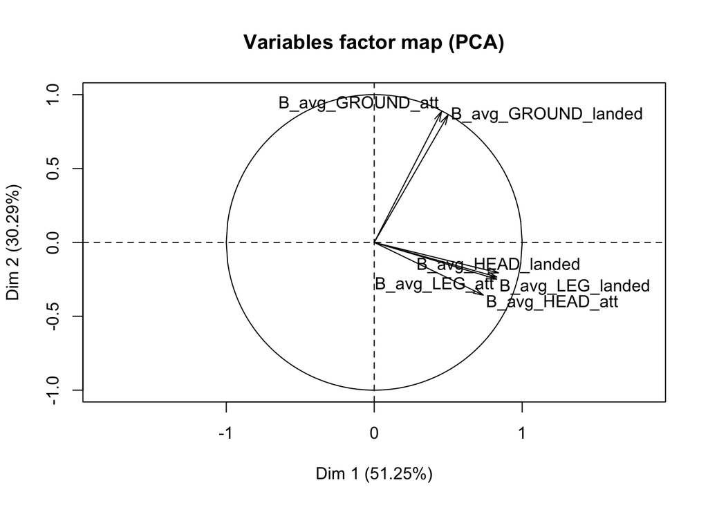

```r
plot.PCA(res, choix = "var", axes=c(1,2))
```

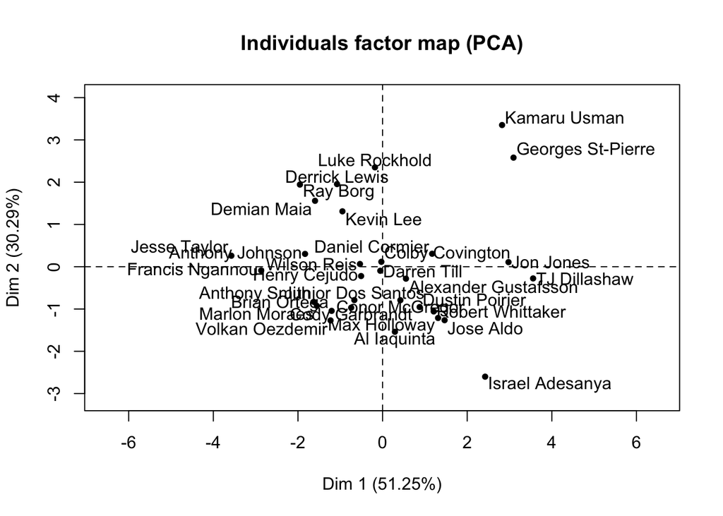

```r
plot.PCA(res, choix = "ind", axes=c(1,2))
```

On peut constater que les variables sont plutôt bien représentées par les 2 premières composantes (51.25% + 30.29% = 81.54%). On ne perd donc pas beaucoup d’informations sur le premier plan factoriel ce qui nous permet de faire une interprétation fiable de la map factorielle des individus ainsi que sa map factorielle des individus associés.

On remarque que sur le premier plan factoriel les variables en relations avec les attaques au sols sont mieux représentées que les attaques en striking car les flèches sont plus proches du cercle de corrélation.

### Répresentation sur le deuxième plan factoriel

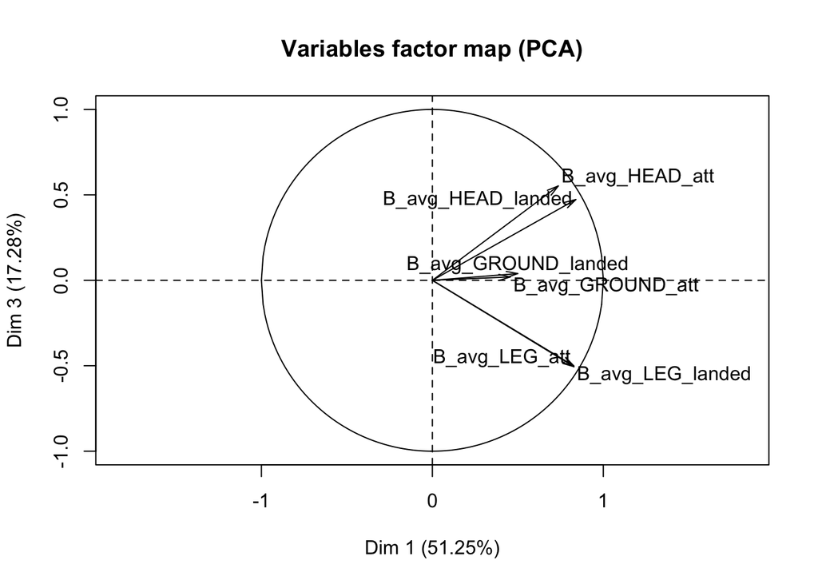

```r
plot.PCA(res, choix = "var", axes=c(1,3))
```

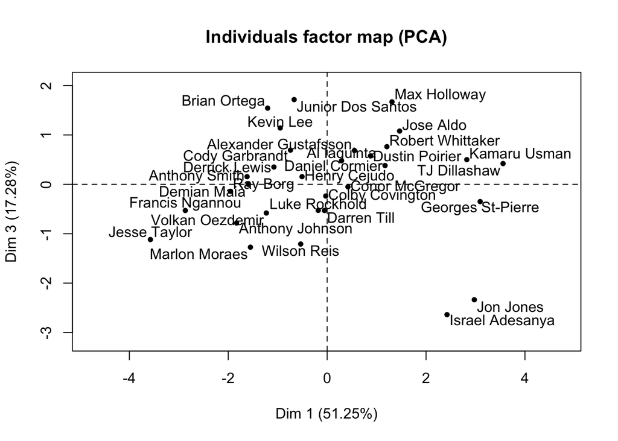

```r
plot.PCA(res, choix = "ind", axes=c(1,3))
```

Sur le 2ème plan factoriel (Dim 1 et Dim 3), on remarque que les variables sont représentées à 68.53% (51.25% + 17.28%). On perd donc plus d’informations sur le premier plan factoriel mais celà reste raisonnable. On peut constater à l’inverse que les attaques en striking sont mieux représentées que les attaques au sol car les flèches sont plus proches du cercle de corrélation.

Sur le 2eme plan factoriel, on peut encore améliorer notre interprétation à propos d’Israel Adesanya. On peut constater qu’il utilise énormément ces jambes afin de kicker son ardversaire aux jambes et le déstabiliser tout comme Jon Jones qui fut l’ancien champion du monde , poids lourd-léger.

# Clustering

On met à l’échelle les données quantitatives.

```r
head(quantitativeVariables)
```

| B_avg_HEAD_landed | B_avg_LEG_landed | B_avg_GROUND_landed | B_avg_HEAD_att | B_avg_LEG_att | B_avg_GROUND_att |
| --- | --- | --- | --- | --- | --- |
| 11.20000 | 5.400000 | 2.000000 | 48.60000 | 7.600000 | 2.600000 |
| 40.66667 | 6.619048 | 5.095238 | 90.47619 | 8.095238 | 8.095238 |
| 32.60000 | 17.200000 | 1.600000 | 77.40000 | 20.200000 | 2.000000 |
| 24.10000 | 2.900000 | 2.200000 | 54.70000 | 3.200000 | 2.900000 |
| 39.11111 | 7.555556 | 23.777778 | 90.22222 | 8.888889 | 33.222222 |
| 45.73333 | 11.133333 | 12.400000 | 133.06667 | 14.533333 | 16.533333 |

```r
scaledQuantitativeVariables <- scale(quantitativeVariables)
head(scaledQuantitativeVariables)
```

```
                B_avg_HEAD_landed B_avg_LEG_landed B_avg_GROUND_landed
Marlon Moraes          -1.4715469     -0.007572849          -0.9624239
Dustin Poirier          1.1507696      0.304131228          -0.4157617
Israel Adesanya         0.4328956      3.009625208          -1.0330695
Anthony Smith          -0.3235418     -0.646809725          -0.9271011
Kamaru Usman            1.0123366      0.543591391           2.8838351
TJ Dillashaw            1.6016656      1.458410388           0.8743610
                B_avg_HEAD_att B_avg_LEG_att B_avg_GROUND_att
Marlon Moraes       -0.8046850     0.1555500       -1.0765510
Dustin Poirier       0.6116048     0.2560023       -0.3547927
Israel Adesanya      0.1693565     2.7112870       -1.1553565
Anthony Smith       -0.5983776    -0.7369295       -1.0371483
Kamaru Usman         0.6030154     0.4169835        2.9454482
TJ Dillashaw         2.0520524     1.5618815        0.7534878
```

# KMeans clustering

```r
# On utilise 3 classes ici.

classification <- kmeans(scaledQuantitativeVariables, centers = 3)
classification$cluster
```

```
       Marlon Moraes       Dustin Poirier      Israel Adesanya
                   1                    3                    3
       Anthony Smith         Kamaru Usman         TJ Dillashaw
                   1                    2                    3
Alexander Gustafsson         Brian Ortega        Derrick Lewis
                   3                    1                    2
      Conor McGregor          Darren Till       Cody Garbrandt
                   3                    1                    1
        Henry Cejudo       Daniel Cormier      Colby Covington
                   1                    3                    1
         Al Iaquinta        Luke Rockhold      Francis Ngannou
                   3                    2                    1
     Volkan Oezdemir            Jose Aldo    Georges St-Pierre
                   1                    3                    2
           Kevin Lee             Ray Borg            Jon Jones
                   2                    2                    3
         Demian Maia     Robert Whittaker         Jesse Taylor
                   2                    3                    1
        Max Holloway    Junior Dos Santos          Wilson Reis
                   3                    1                    1
     Anthony Johnson
                   1
```

```r
BSS <- classification$betweenss
TSS <- classification$totss
qualityPartition = (BSS / TSS) * 100
```

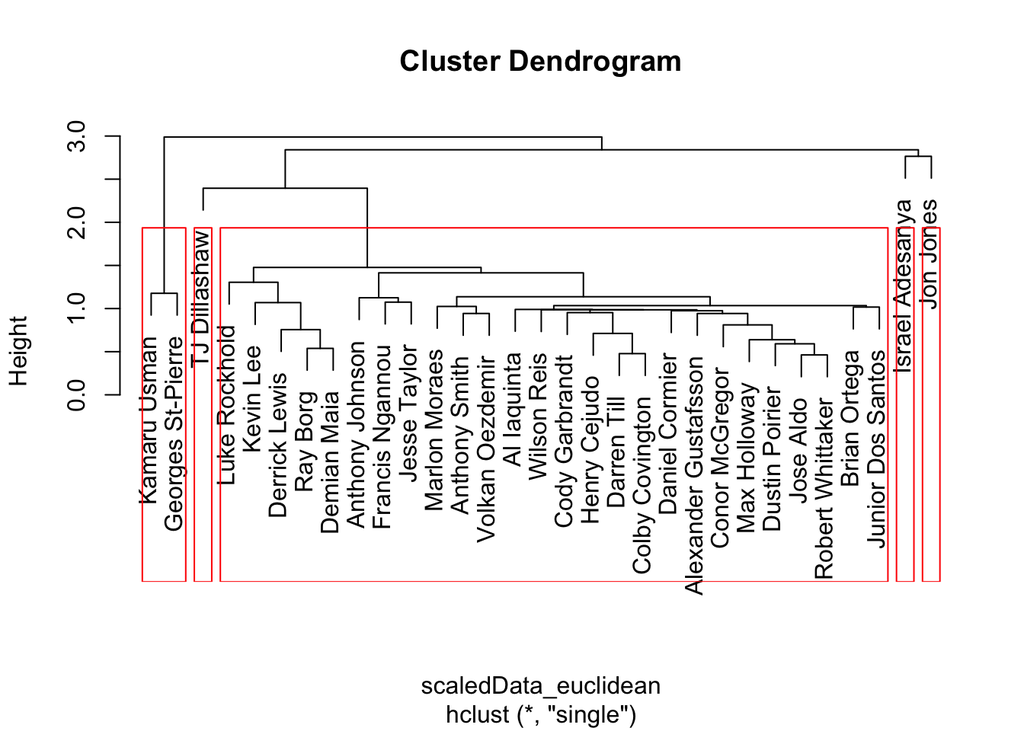

```r
#Classification Hierarchique
# Distance euclidienne
scaledData_euclidean <- dist(scaledQuantitativeVariables, method = "euclidean")

# Classification hiérarchique saut minimum (single linkage)
scaledData_single <- hclust(scaledData_euclidean, method = "single")

# Dendrogramme
plot(scaledData_single)
rect.hclust(scaledData_single, k=5, border="red")
```

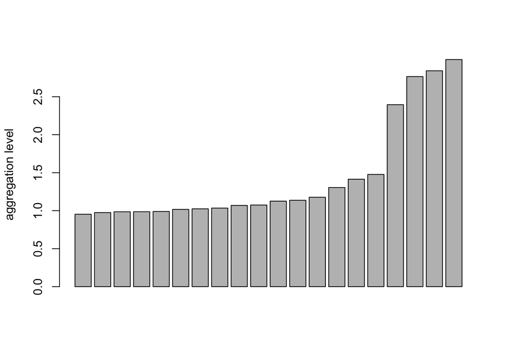

```r
# Les niveaux d'aggregation se trouvent dans la partie $height de l'objet rendu par hclust()
barplot(tail(scaledData_single$height, n = 20),ylab = "aggregation level")
```

Algorithme de Ward

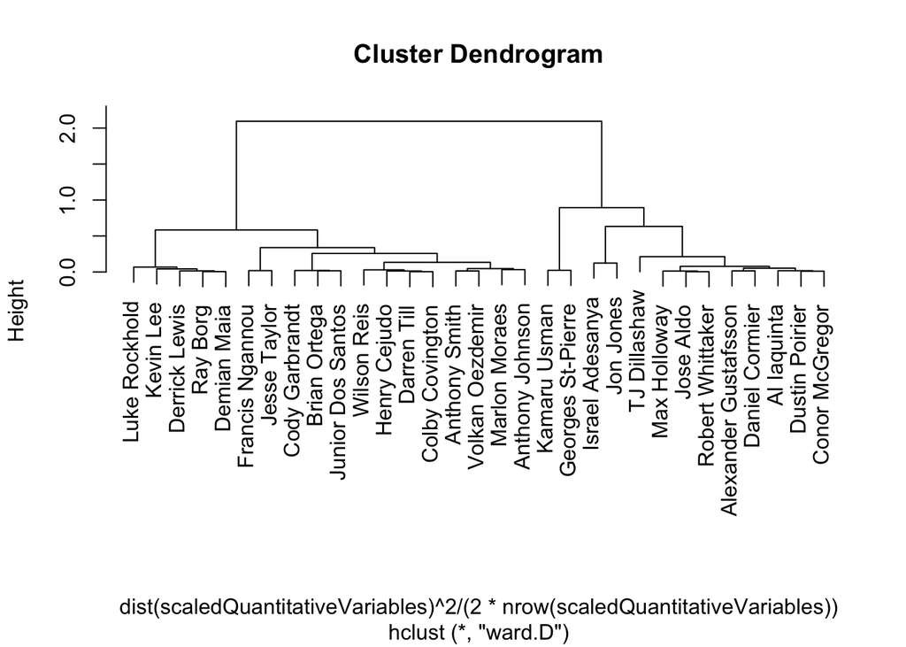

```r
#Classification Hierarchique
hclust_ward <- hclust(dist(scaledQuantitativeVariables)^2 / (2 * nrow(scaledQuantitativeVariables)), method = "ward.D")

plot(hclust_ward)
```

```r
hclust_ward$height
```

```
 [1] 0.003452081 0.003680759 0.004673996 0.010605274 0.012412708
 [6] 0.012824230 0.014345337 0.015330457 0.015610815 0.016688261
[11] 0.017571358 0.018618973 0.019865447 0.022343120 0.029063046
[16] 0.032254083 0.042428534 0.046685854 0.052729397 0.067504862
[21] 0.077710302 0.123308904 0.133597186 0.213175362 0.257183169
[26] 0.338323086 0.583310152 0.633205462 0.893405835 2.094543562
```

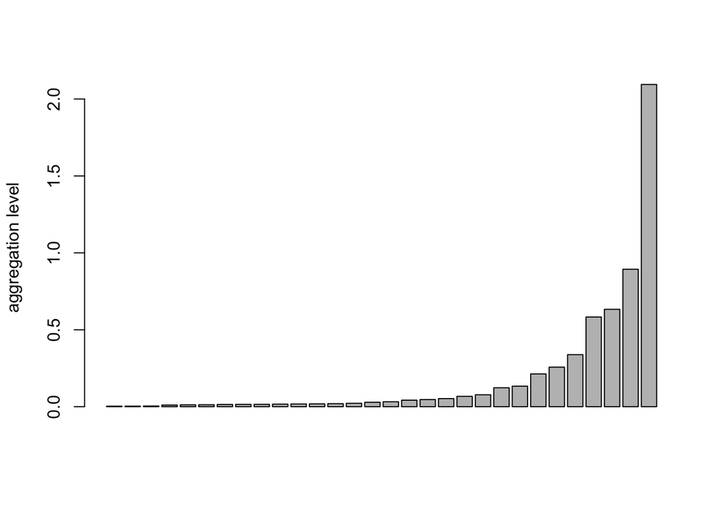

```r
barplot(hclust_ward$height,ylab = "aggregation level")
```

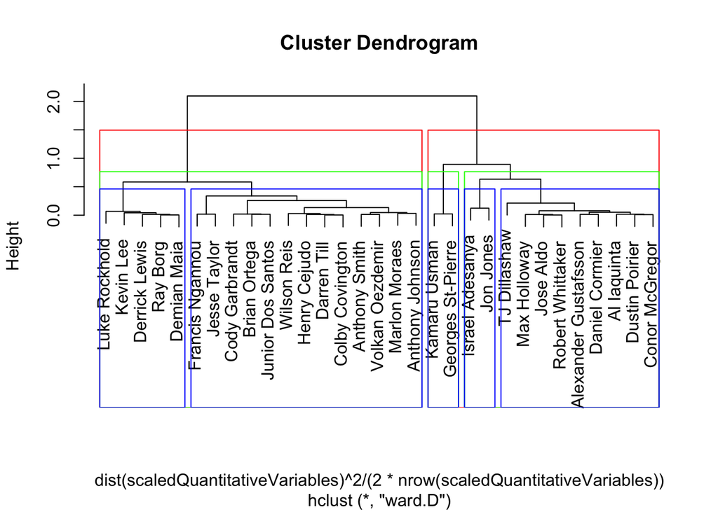

```r
plot(hclust_ward)
rect.hclust(hclust_ward, k=2, border="red")
rect.hclust(hclust_ward, k=3, border="green")
rect.hclust(hclust_ward, k=5, border = "blue")
```

```r
TSS <- sum(hclust_ward$height)
BSS <- sum(tail(hclust_ward$height,n=(5-1)))
BSS/TSS*100
```

```
[1] 72.41023
```

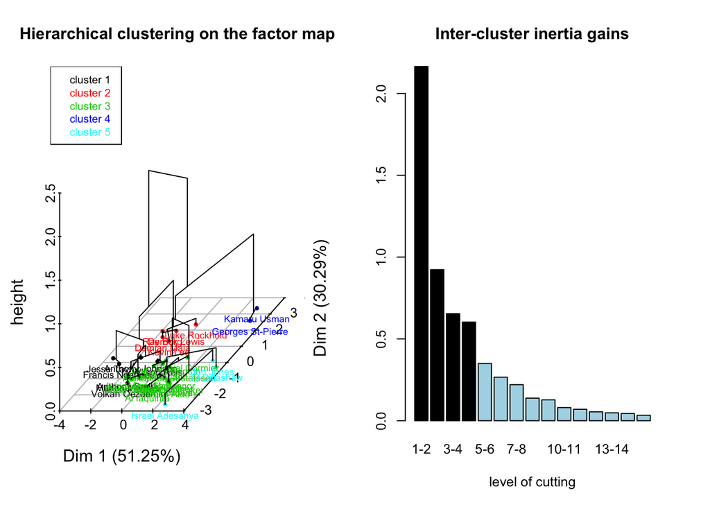

```r
library(FactoMineR) # pour faire une PCA
# Principal component analysis, 2 components
res.pca <- PCA(quantitativeVariables, scale.unit = TRUE, ncp = 6, graph = FALSE)
# Hierarchical cluster analysis (Ward) based on results of PCA
# number of clusters chosen automatically with nb.clust = -1
res.hcpc <- HCPC(res.pca, nb.clust = -1, graph = FALSE)
par(mfrow = c(1, 2), cex = 0.8) # 2 figures; reduce font size
plot(res.hcpc, choice = "3D.map") # projected observations and dendrogram
plot(res.hcpc, choice = "bar")    # aggregation levels
```

# Analyse des correspondances

```r
head(dataCleaned)
```

| weight_class | B_current_win_streak | B_longest_win_streak | B_age | B_win_by_Submission | B_win_by_KO.TKO | B_avg_HEAD_landed | B_avg_LEG_landed | B_avg_GROUND_landed | B_avg_HEAD_att | B_avg_LEG_att | B_avg_GROUND_att |
| --- | --- | --- | --- | --- | --- | --- | --- | --- | --- | --- | --- |
| Bantamweight | 4 | 4 | 31 | 1 | 2 | 11.20000 | 5.400000 | 2.000000 | 48.60000 | 7.600000 | 2.600000 |
| Lightweight | 3 | 4 | 30 | 3 | 8 | 40.66667 | 6.619048 | 5.095238 | 90.47619 | 8.095238 | 8.095238 |
| Middleweight | 5 | 5 | 29 | 0 | 2 | 32.60000 | 17.200000 | 1.600000 | 77.40000 | 20.200000 | 2.000000 |
| Light Heavyweight | 3 | 3 | 30 | 1 | 5 | 24.10000 | 2.900000 | 2.200000 | 54.70000 | 3.200000 | 2.900000 |
| Welterweight | 9 | 9 | 31 | 1 | 1 | 39.11111 | 7.555556 | 23.777778 | 90.22222 | 8.888889 | 33.222222 |
| Flyweight | 4 | 4 | 32 | 1 | 7 | 45.73333 | 11.133333 | 12.400000 | 133.06667 | 14.533333 | 16.533333 |

```r
dataNumeric <- dataCleaned[2:12]
round(rowSums(dataNumeric), digits = 2)
```

```
       Marlon Moraes       Dustin Poirier      Israel Adesanya
              119.40               207.05               192.00
       Anthony Smith         Kamaru Usman         TJ Dillashaw
              132.00               253.78               281.40
Alexander Gustafsson         Brian Ortega        Derrick Lewis
              204.21               179.71               154.40
      Conor McGregor          Darren Till       Cody Garbrandt
              185.40               154.33               164.57
        Henry Cejudo       Daniel Cormier      Colby Covington
              162.50               211.09               172.00
         Al Iaquinta        Luke Rockhold      Francis Ngannou
              194.60               153.88                95.50
     Volkan Oezdemir            Jose Aldo    Georges St-Pierre
              126.33               230.30               262.62
           Kevin Lee             Ray Borg            Jon Jones
              165.00               105.57               229.88
         Demian Maia     Robert Whittaker         Jesse Taylor
              149.28               221.55                57.00
        Max Holloway    Junior Dos Santos          Wilson Reis
              247.56               191.00               141.88
     Anthony Johnson
              119.94
```

```r
round(colMeans(dataNumeric), digits = 2)
```

```
B_current_win_streak B_longest_win_streak                B_age
                4.23                 5.65                30.52
 B_win_by_Submission      B_win_by_KO.TKO    B_avg_HEAD_landed
                1.52                 3.77                27.74
    B_avg_LEG_landed  B_avg_GROUND_landed       B_avg_HEAD_att
                5.43                 7.45                72.39
       B_avg_LEG_att     B_avg_GROUND_att
                6.83                10.80
```

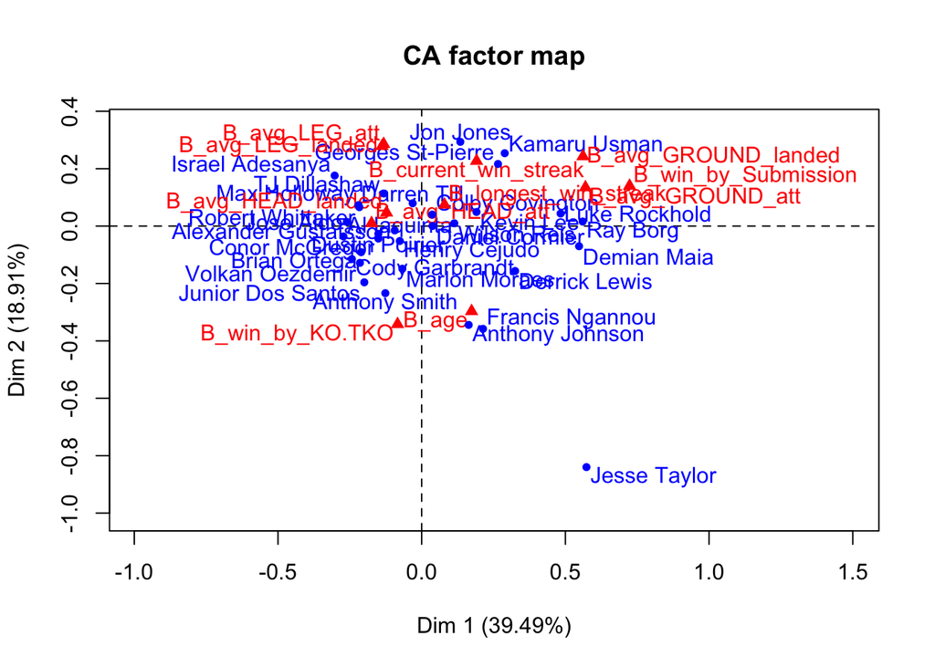

```r
dataCA <- CA(dataNumeric, ncp = 5, graph = FALSE)
plot(dataCA)
```

```r
round(dataCA$eig, digits = 2)
```

| eigenvalue | percentage of variance | cumulative percentage of variance |
| --- | --- | --- |
| 0.06 | 39.49 | 39.49 |
| 0.03 | 18.91 | 58.40 |
| 0.02 | 15.58 | 73.98 |
| 0.02 | 10.70 | 84.68 |
| 0.01 | 9.08 | 93.76 |
| 0.01 | 3.77 | 97.53 |
| 0.00 | 1.39 | 98.93 |
| 0.00 | 0.80 | 99.73 |
| 0.00 | 0.21 | 99.94 |
| 0.00 | 0.06 | 100.00 |

```r
#sorties clefs colonnes
lapply(dataCA$col, round, 2)
```

```
$coord
                     Dim 1 Dim 2 Dim 3 Dim 4 Dim 5
B_current_win_streak  0.19  0.23  0.17 -0.23  0.41
B_longest_win_streak  0.08  0.07 -0.02 -0.06  0.23
B_age                 0.17 -0.30  0.14 -0.03 -0.05
B_win_by_Submission   0.72  0.14 -0.10 -0.95  0.24
B_win_by_KO.TKO      -0.08 -0.34 -0.07  0.44  0.53
B_avg_HEAD_landed    -0.12  0.05 -0.07  0.03  0.01
B_avg_LEG_landed     -0.14  0.28  0.46  0.08 -0.04
B_avg_GROUND_landed   0.56  0.24 -0.15  0.13 -0.04
B_avg_HEAD_att       -0.17  0.01 -0.08 -0.03 -0.03
B_avg_LEG_att        -0.13  0.29  0.46  0.08 -0.03
B_avg_GROUND_att      0.57  0.13 -0.10  0.14 -0.09

$contrib
                     Dim 1 Dim 2 Dim 3 Dim 4 Dim 5
B_current_win_streak  1.45  4.27  2.81  8.07 28.55
B_longest_win_streak  0.34  0.61  0.03  0.68 12.11
B_age                 8.67 52.78 13.59  1.04  3.41
B_win_by_Submission   7.47  0.59  0.34 47.10  3.62
B_win_by_KO.TKO       0.25  8.67  0.43 25.43 44.22
B_avg_HEAD_landed     3.90  1.20  3.41  0.88  0.14
B_avg_LEG_landed      0.97  8.29 27.46  1.23  0.36
B_avg_GROUND_landed  22.09  8.65  4.14  4.63  0.38
B_avg_HEAD_att       20.73  0.14 11.03  2.41  3.45
B_avg_LEG_att         1.12 10.95 34.13  1.49  0.21
B_avg_GROUND_att     33.00  3.85  2.65  7.03  3.55

$cos2
                     Dim 1 Dim 2 Dim 3 Dim 4 Dim 5
B_current_win_streak  0.09  0.12  0.07  0.13  0.39
B_longest_win_streak  0.05  0.04  0.00  0.03  0.43
B_age                 0.21  0.62  0.13  0.01  0.02
B_win_by_Submission   0.30  0.01  0.01  0.51  0.03
B_win_by_KO.TKO       0.01  0.18  0.01  0.30  0.44
B_avg_HEAD_landed     0.48  0.07  0.17  0.03  0.00
B_avg_LEG_landed      0.06  0.24  0.66  0.02  0.01
B_avg_GROUND_landed   0.75  0.14  0.06  0.04  0.00
B_avg_HEAD_att        0.76  0.00  0.16  0.02  0.03
B_avg_LEG_att         0.05  0.25  0.65  0.02  0.00
B_avg_GROUND_att      0.85  0.05  0.03  0.05  0.02

$inertia
 [1] 0.01 0.00 0.02 0.02 0.01 0.00 0.01 0.02 0.02 0.01 0.02
```

```r
#sorties clefs lignes
lapply(dataCA$row, round, 2)
```

```
$coord
                     Dim 1 Dim 2 Dim 3 Dim 4 Dim 5
Marlon Moraes        -0.07 -0.15  0.29 -0.11  0.00
Dustin Poirier       -0.15 -0.03 -0.04  0.01  0.06
Israel Adesanya      -0.30  0.18  0.43  0.02 -0.05
Anthony Smith        -0.13 -0.23  0.01 -0.02  0.07
Kamaru Usman          0.29  0.25 -0.10  0.10 -0.07
TJ Dillashaw         -0.13  0.11 -0.03  0.09 -0.06
Alexander Gustafsson -0.09 -0.02 -0.09  0.00 -0.03
Brian Ortega         -0.21 -0.09 -0.19 -0.23  0.06
Derrick Lewis         0.33 -0.16 -0.14  0.30  0.15
Conor McGregor       -0.15 -0.04  0.03  0.12  0.04
Darren Till          -0.03  0.08  0.07  0.06 -0.06
Cody Garbrandt       -0.24 -0.11 -0.11  0.02 -0.06
Henry Cejudo         -0.08 -0.05 -0.02  0.00 -0.16
Daniel Cormier        0.04  0.00 -0.02 -0.02 -0.14
Colby Covington       0.04  0.04  0.03 -0.06 -0.04
Al Iaquinta          -0.27 -0.04  0.00 -0.03  0.00
Luke Rockhold         0.48  0.04 -0.03  0.11 -0.10
Francis Ngannou       0.21 -0.36  0.16 -0.10  0.29
Volkan Oezdemir      -0.21 -0.13  0.17 -0.04 -0.04
Jose Aldo            -0.26  0.01 -0.08  0.00 -0.15
Georges St-Pierre     0.27  0.22  0.02  0.09  0.07
Kevin Lee             0.19  0.05 -0.25 -0.16 -0.03
Ray Borg              0.56  0.02 -0.16  0.00 -0.17
Jon Jones             0.13  0.29  0.27 -0.08  0.18
Demian Maia           0.55 -0.07 -0.03 -0.44  0.12
Robert Whittaker     -0.22  0.07 -0.05  0.01  0.04
Jesse Taylor          0.57 -0.84  0.42 -0.01 -0.43
Max Holloway         -0.22  0.07 -0.12 -0.08  0.13
Junior Dos Santos    -0.20 -0.20 -0.19  0.07  0.07
Wilson Reis           0.11  0.01  0.19 -0.08 -0.16
Anthony Johnson       0.16 -0.34  0.12  0.31  0.27

$contrib
                     Dim 1 Dim 2 Dim 3 Dim 4 Dim 5
Marlon Moraes         0.16  1.67  7.66  1.69  0.00
Dustin Poirier        1.43  0.09  0.26  0.01  1.09
Israel Adesanya       5.35  3.77 27.51  0.12  0.53
Anthony Smith         0.64  4.57  0.01  0.06  0.89
```

[output cut: 51 more lines]

```
Kevin Lee             0.28  0.02  0.49  0.19  0.01
Ray Borg              0.84  0.00  0.07  0.00  0.08
Jon Jones             0.08  0.39  0.34  0.03  0.15
Demian Maia           0.56  0.01  0.00  0.36  0.03
Robert Whittaker      0.77  0.07  0.04  0.00  0.03
Jesse Taylor          0.23  0.49  0.12  0.00  0.13
Max Holloway          0.50  0.05  0.16  0.07  0.17
Junior Dos Santos     0.29  0.28  0.26  0.03  0.04
Wilson Reis           0.15  0.00  0.42  0.08  0.29
Anthony Johnson       0.08  0.34  0.04  0.28  0.21

$inertia
 [1] 0.00 0.00 0.01 0.00 0.01 0.00 0.00 0.01 0.01 0.00 0.00 0.00 0.00 0.00
[15] 0.00 0.00 0.01 0.01 0.00 0.00 0.01 0.00 0.01 0.01 0.01 0.00 0.01 0.00
[29] 0.00 0.00 0.01
```

```r
round(sort(rowSums(dataCA$col$cos2[,1:2])), digits = 3)
```

```
B_longest_win_streak      B_win_by_KO.TKO B_current_win_streak
               0.096                0.192                0.206
    B_avg_LEG_landed        B_avg_LEG_att  B_win_by_Submission
               0.299                0.308                0.308
   B_avg_HEAD_landed       B_avg_HEAD_att                B_age
               0.552                0.764                0.838
 B_avg_GROUND_landed     B_avg_GROUND_att
               0.888                0.895
```

```r
round(dataCA$col$contrib[,c(1,2)], digits = 3)
```

```
                      Dim 1  Dim 2
B_current_win_streak  1.452  4.275
B_longest_win_streak  0.336  0.611
B_age                 8.665 52.777
B_win_by_Submission   7.470  0.586
B_win_by_KO.TKO       0.250  8.672
B_avg_HEAD_landed     3.901  1.199
B_avg_LEG_landed      0.972  8.286
B_avg_GROUND_landed  22.093  8.645
B_avg_HEAD_att       20.734  0.142
B_avg_LEG_att         1.124 10.954
B_avg_GROUND_att     33.003  3.854
```

```r
dataCleaned["B_age"]
```

| B_age |
| --- |
| 31 |
| 30 |
| 29 |
| 30 |
| 31 |
| 32 |
| 31 |
| 27 |
| 33 |
| 30 |

[output cut: 21 more lines]

# Annexes

## Règles de mma

Comment se déroule un combat de mma. Ce dernier implique 2 combattants et est régulé par un arbitre. Le combat prend place dans une cage appelé octogone (car cage de 8 cotés) et comporte 3 rounds de 5 minutes excepté pour un combat d’un titre de champion du monde, il est alors de 5 rounds de 5 minutes. Le mma est composé de 70 règles mais celles-ci ne sont pas importantes afin de comprendre ce projet. Cependant, il faut comprendre que le combat peut se dérouler en 3 phases à chaque moment.

1. Le striking (combat pied, poings, genoux, coup de coude) se pratique en position debout. Il admet la possibilité de mettre un adversaire KO.

[figure not shown]

Striking

2. La takedown (prises de lutte ou de judo) permet de déstabiliser l’adversaire et de soit l’amener au sol soit le maintenir au sol.

[figure not shown]

Takedown

3. La submission (prise de jiujitsu brésilien ou luta livre) permet de garder son adversaire au sol et de le soumettre en utilisant par exemple des étranglements, des clefs ou encore des compressions musculaires.

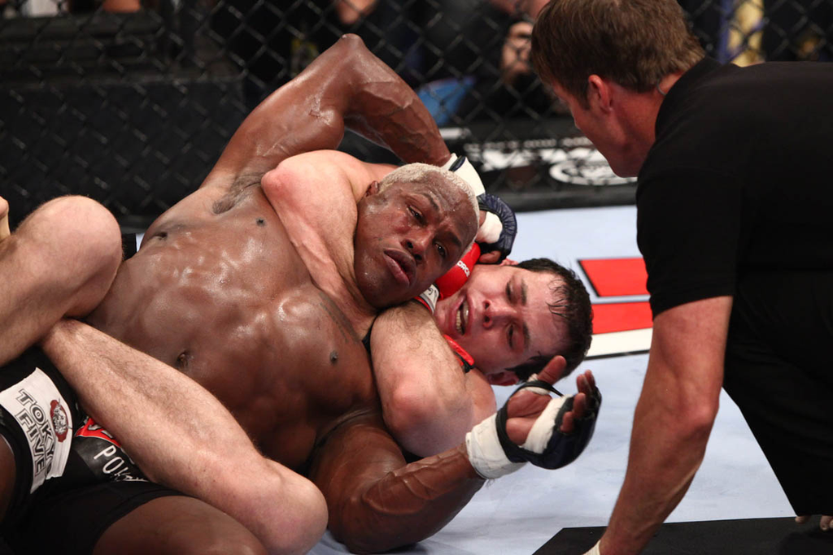

Submission

Il y a plusieurs manières de gagner un combat :

1. Gagner par arrêt du docteur
2. Gagner par KO technique (Soit l’adversaire est ko soit l’arbitre arrête le combat car le combattant est quasi ko).
3. Gagner par soumission
4. Gagner par décision (Il y a 2 types de décisions). 4.1) Gagner par décision unanime. 4.2) Gagner par split décision.

Si le combat ne se termine pas par un ko, une soumission ou un arret du docteur après les 3 ou 5 rounds, ce sont les 3 juges qui prennent la décision de nommer le vainqueur. Les décisions se prennent en fonction du nombre d’actions tentées par chaque adversaire. A chaque action correspond un nombre de points bien précis.

Maintenant que tout est clarifié, nous pouvons commencer le projet en important les données.